# European Survey - What is the political sentiment in German speaking Countries Before Covid?

Milica Pajkic and Marco Rieder

2022-11-21

# Getting the Data and installing libraries

```
## [1] "ESS9e03_1"
```

```
## [1] 1 2
```

```
##  [1] "AT" "BE" "BG" "CH" "CY" "CZ" "DE" "DK" "EE" "ES" "FI" "FR" "GB" "HR" "HU"
## [16] "IE" "IS" "IT" "LT" "LV" "ME" "NL" "NO" "PL" "PT" "RS" "SE" "SI" "SK"
```

# 1. Introduction

## 1.1 Selection of parameters

The survey is really comprehensive and consists out of 572 variables. Some of them are related to others and only answered by a subset of participants.

## 1.2 Goal

# 2. Descriptive Statistics

```
##    Min. 1st Qu.  Median    Mean 3rd Qu.    Max.
##       0      30      60     187      90    9999
```

```
## [1] 0
```

```
##    Min. 1st Qu.  Median    Mean 3rd Qu.    Max.
##   1.000   1.000   1.000   1.486   2.000   2.000
```

```
## [1] 0
```

```
## [1] "double"
```

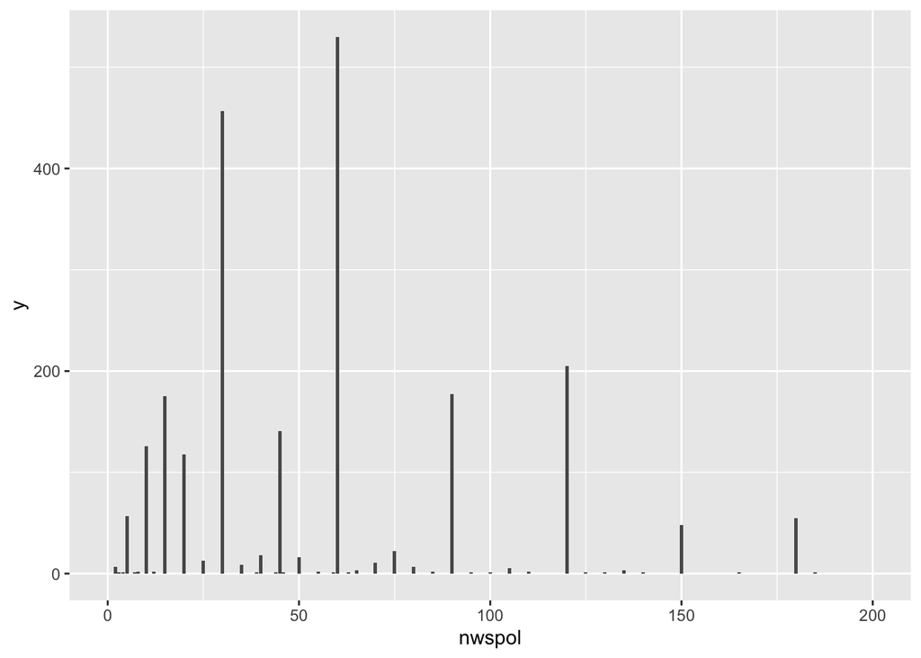

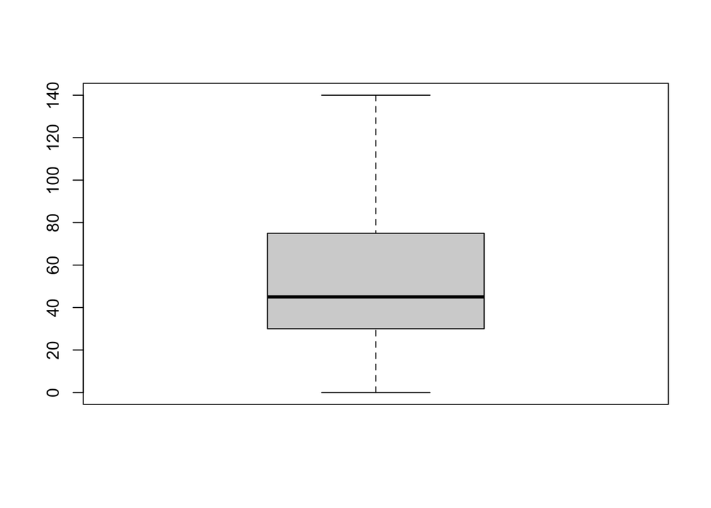

### **Was muss man alles für eine deskriptive Analyse machen?**

```
## [1] "double"
```

```
##    Min. 1st Qu.  Median    Mean 3rd Qu.    Max.
##       0       0       6      43       7    8888
```

```
## [1] 0
```

# 3. Models

## 3.1 Linear Model

```
##
## Call:
## lm(formula = nwspol ~ eduade3, data = ess9_de)
##
## Residuals:
##    Min     1Q Median     3Q    Max
## -974.4  -33.4  -17.2   11.6 7883.6
##
## Coefficients:
##              Estimate Std. Error t value Pr(>|t|)
## (Intercept) 62.165563   3.919430   15.86   <2e-16 ***
## eduade3      0.106014   0.006964   15.22   <2e-16 ***
## ---
## Signif. codes:  0 '***' 0.001 '**' 0.01 '*' 0.05 '.' 0.1 ' ' 1
##
## Residual standard error: 189.8 on 2356 degrees of freedom
## Multiple R-squared:  0.08955,    Adjusted R-squared:  0.08916
## F-statistic: 231.7 on 1 and 2356 DF,  p-value: < 2.2e-16
```

## 3.2 GLM Poisson

```
## [1] 572
```

```
## [1] 708
```

```
## [1] 1752
```

```
## [1] 222
```

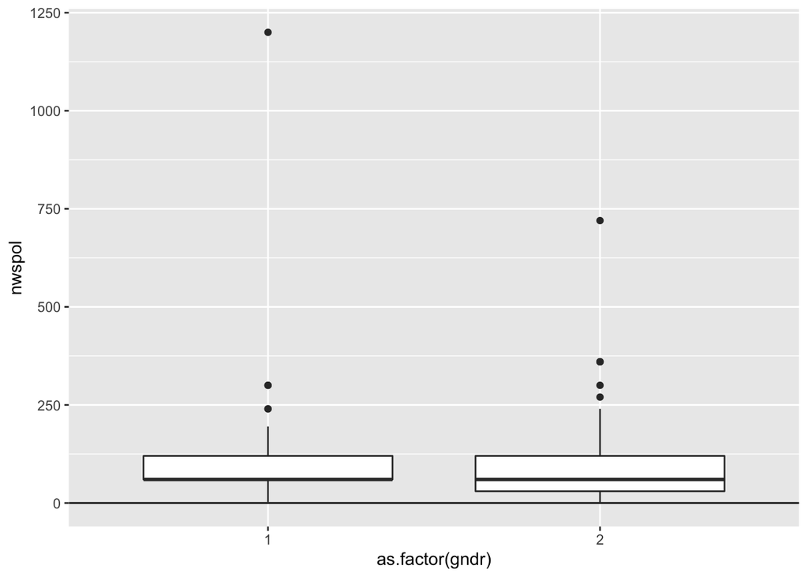

```
##
## Call:
## glm(formula = nwspol ~ polintr + eduyrs + netusoft + stfeco +
##     stfgov + stfdem + gndr + agea + rlgdgr, family = "poisson",
##     data = ess9_poisson)
##
## Deviance Residuals:
##     Min       1Q   Median       3Q      Max
## -14.893   -5.297   -2.219    1.777   53.181
##
## Coefficients:
##               Estimate Std. Error z value Pr(>|z|)
## (Intercept)  3.9426859  0.1166426  33.801  < 2e-16 ***
## polintr     -0.2289094  0.0089985 -25.439  < 2e-16 ***
## eduyrs       0.0065907  0.0015506   4.251 2.13e-05 ***
## netusoft    -0.0898335  0.0160252  -5.606 2.07e-08 ***
## stfeco      -0.0099345  0.0039373  -2.523   0.0116 *
## stfgov      -0.0972591  0.0037499 -25.936  < 2e-16 ***
## stfdem       0.0453339  0.0038252  11.851  < 2e-16 ***
## gndr        -0.0701814  0.0143494  -4.891 1.00e-06 ***
## agea         0.0221268  0.0009495  23.303  < 2e-16 ***
## rlgdgr       0.0369782  0.0023170  15.960  < 2e-16 ***
## ---
## Signif. codes:  0 '***' 0.001 '**' 0.01 '*' 0.05 '.' 0.1 ' ' 1
##
## (Dispersion parameter for poisson family taken to be 1)
##
##     Null deviance: 19154  on 274  degrees of freedom
## Residual deviance: 16375  on 265  degrees of freedom
## AIC: 17962
##
## Number of Fisher Scoring iterations: 5
```

Now we simulate with our model the average media consumption for Females and Males.

```
## [1] 275
```

```
##   sim_1
## 1   129
## 2   101
## 3    99
## 4    60
## 5    60
## 6    39
```

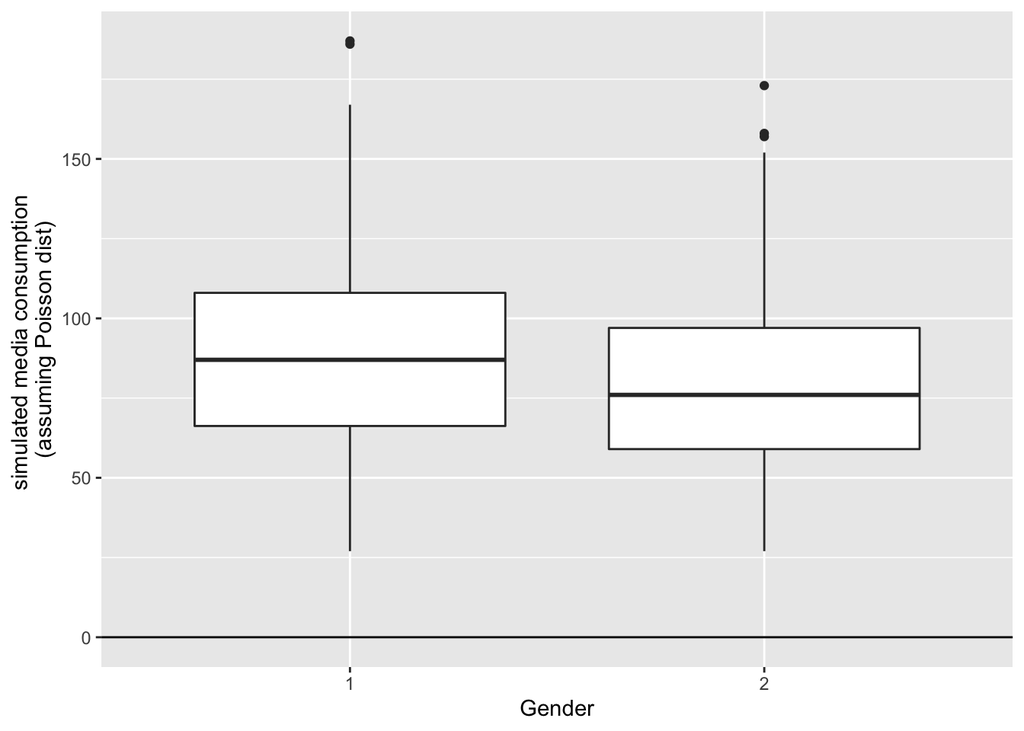

### 3.2.1 GLM Quasi-Poisson

```
##
## Call:
## glm(formula = nwspol ~ eduyrs + stfeco + stfgov + stfdem + gndr +
##     agea + rlgdgr, family = "quasipoisson", data = ess9)
##
## Deviance Residuals:
##     Min       1Q   Median       3Q      Max
## -87.391  -14.349  -10.522   -6.247  255.921
##
## Coefficients:
##               Estimate Std. Error t value Pr(>|t|)
## (Intercept)  4.7434822  0.0757553  62.616  < 2e-16 ***
## eduyrs       0.0172609  0.0012819  13.466  < 2e-16 ***
## stfeco       0.0066763  0.0013740   4.859 1.18e-06 ***
## stfgov      -0.0013230  0.0014355  -0.922    0.357
## stfdem       0.0054644  0.0012870   4.246 2.18e-05 ***
## gndr        -0.0147897  0.0444707  -0.333    0.739
## agea         0.0011135  0.0001804   6.173 6.75e-10 ***
## rlgdgr       0.0130078  0.0014871   8.747  < 2e-16 ***
## ---
## Signif. codes:  0 '***' 0.001 '**' 0.01 '*' 0.05 '.' 0.1 ' ' 1
##
## (Dispersion parameter for quasipoisson family taken to be 4517.147)
##
##     Null deviance: 38214041  on 49518  degrees of freedom
## Residual deviance: 36673284  on 49511  degrees of freedom
## AIC: NA
##
## Number of Fisher Scoring iterations: 7
```

## 3.4 GAM

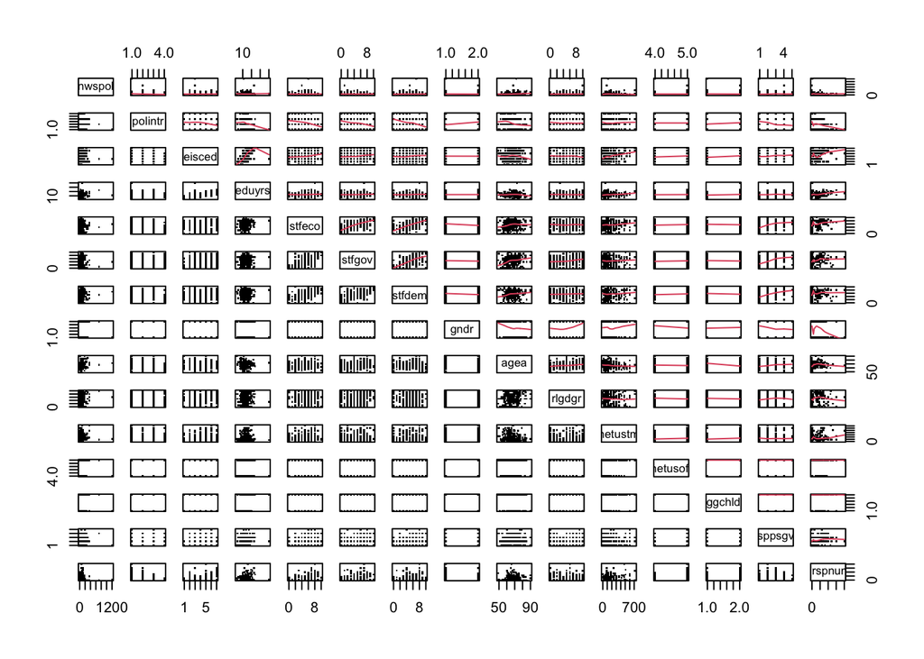

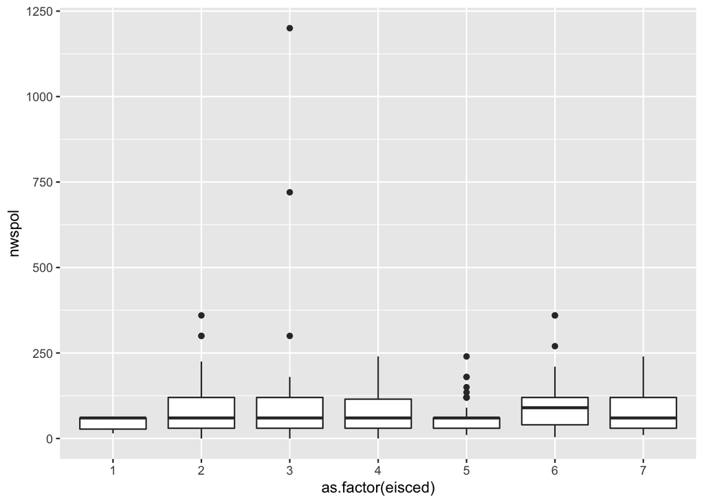

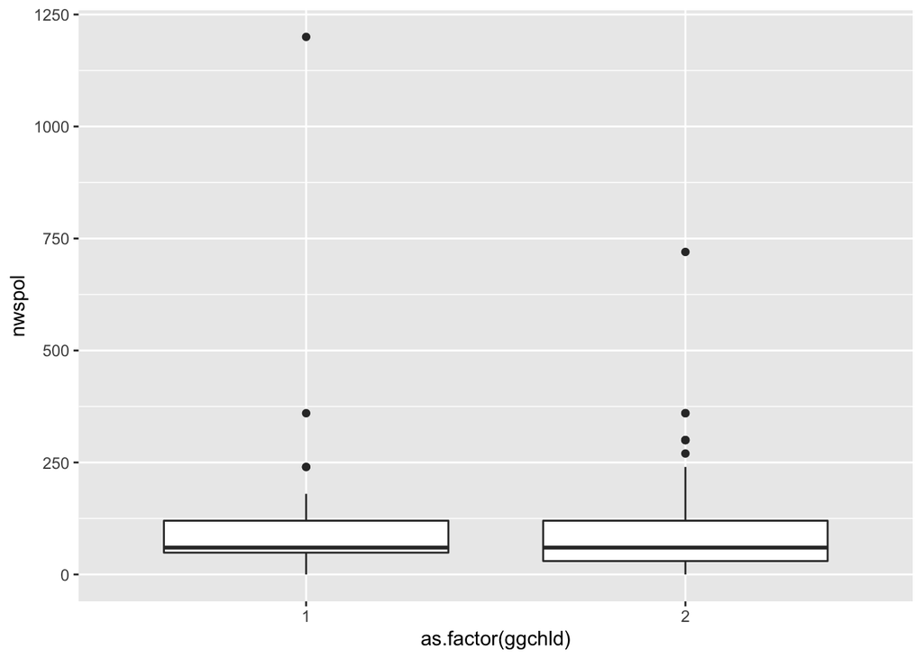

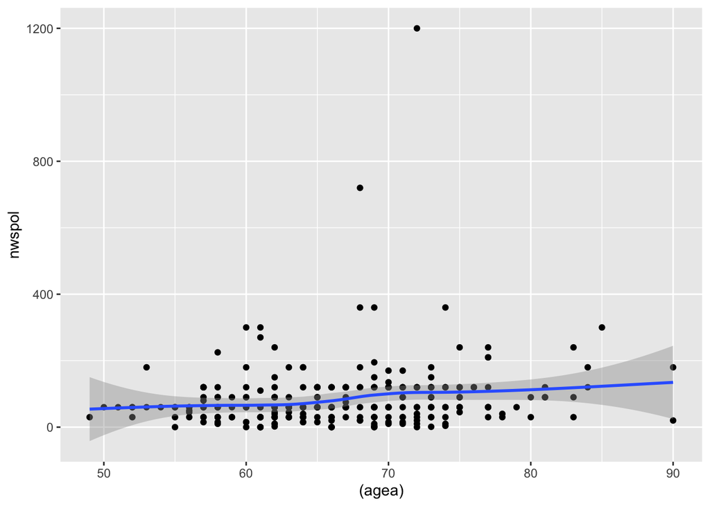

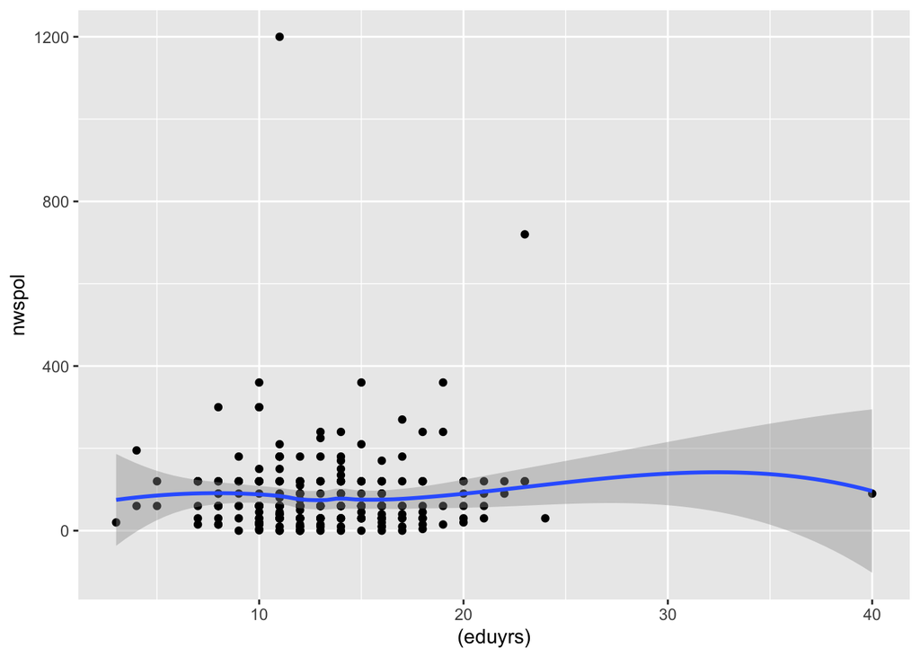

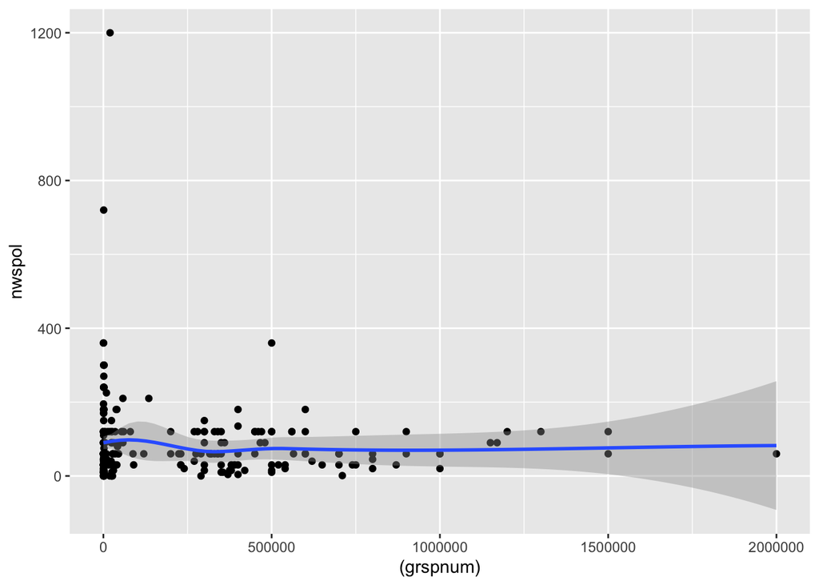

## 3.5 Neural Network

```
## tibble [275 × 15] (S3: tbl_df/tbl/data.frame)
##  $ nwspol  : num [1:275] 60 120 60 30 30 60 30 120 150 120 ...
##  $ polintr : num [1:275] 2 1 1 3 4 3 3 4 3 2 ...
##  $ eisced  : num [1:275] 3 3 2 6 4 4 4 2 4 3 ...
##  $ eduyrs  : num [1:275] 14 12 10 18 11 12 13 7 11 9 ...
##  $ stfeco  : num [1:275] 7 8 7 6 2 4 7 2 2 7 ...
##  $ stfgov  : num [1:275] 4 6 6 6 0 6 3 0 1 7 ...
##  $ stfdem  : num [1:275] 6 8 7 7 0 4 2 0 2 7 ...
##  $ gndr    : num [1:275] 1 1 1 1 1 2 2 2 2 1 ...
##  $ agea    : num [1:275] 77 67 69 70 69 55 56 58 62 84 ...
##  $ rlgdgr  : num [1:275] 10 7 7 0 3 5 5 10 6 7 ...
##  $ netustm : num [1:275] 60 240 180 480 120 420 540 120 120 20 ...
##  $ netusoft: num [1:275] 5 5 5 5 5 5 5 4 4 5 ...
##  $ ggchld  : num [1:275] 2 2 2 2 2 2 2 2 2 1 ...
##  $ psppsgva: num [1:275] 3 2 4 3 1 1 2 1 1 3 ...
##  $ grspnum : num [1:275] 3200 2300 2900 6000 510 650 1000 750 900 2240 ...
```

## Prepare for Training

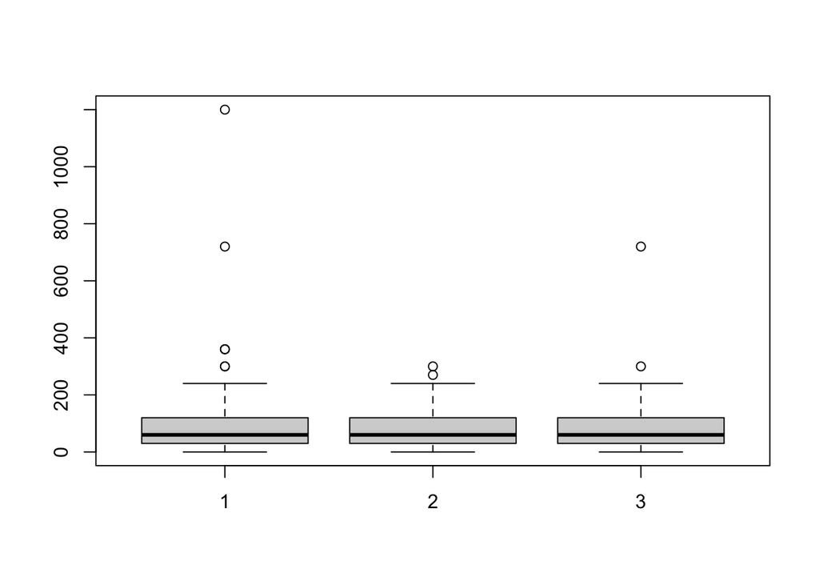

And this time we will also scale the data (by hand for educational purposes)

## Predict the test set

```
##             [,1]
##  [1,] -0.0407299
##  [2,] -0.0407299
##  [3,] -0.0407299
##  [4,] -0.0407299
##  [5,] -0.0407299
##  [6,] -0.0407299
##  [7,] -0.0407299
##  [8,] -0.0407299
##  [9,] -0.0407299
## [10,] -0.0407299
## [11,]  0.1498294
## [12,] -0.0407299
## [13,] -0.0407299
## [14,] -0.0407299
```

[output cut: 39 more lines]

So what went wrong here? Obviously we also need to use the scaled data to make predictions and then scale back to real nwspol values

```
##             [,1]
##  [1,]  82.959704
##  [2,]  60.664370
##  [3,]  83.274550
##  [4,] 112.569102
##  [5,] 116.915003
##  [6,]  48.247354
##  [7,] 106.550631
##  [8,]  29.631205
##  [9,]  87.525749
## [10,]  75.314664
## [11,] 121.622564
## [12,]  90.248793
## [13,] 101.443596
## [14,]   7.580279
```

[output cut: 39 more lines]

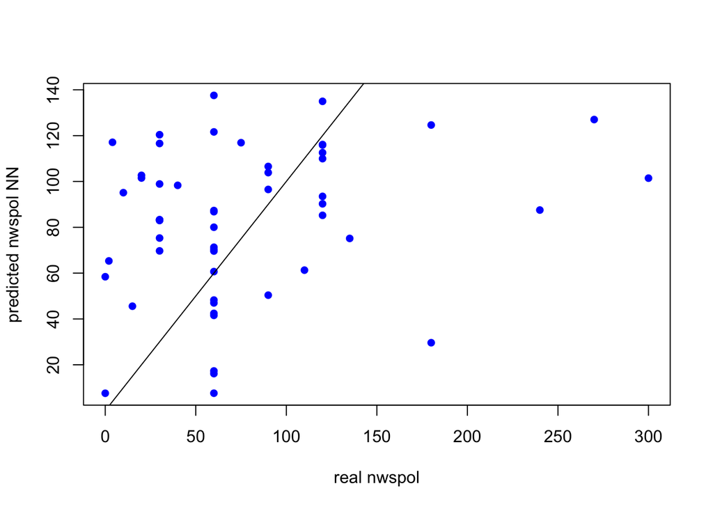

And calculate the RMSE

```
## [1] 64.29686
```

## Redo with `caret` and Cross Validation

In principle we cannot be sure that we were not simply “lucky” with the train/test split above, so the proper way to run this would be via `caret` using k-fold Cross Validation. And also as we use `caret` anyway let’s also run some hyperparameter tuning:

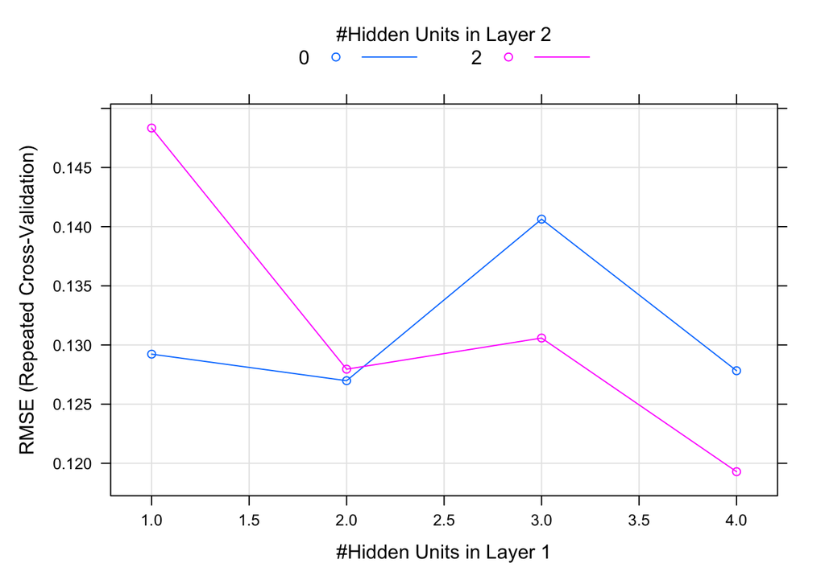

and extract the best model

[figure not shown]

## 3.6 Support Vector Machine